# Lending Club Loans

Chaya Maheshwari, Pedro Henriques, Jada Neumann, Stanislaw Ostoja-Starzewski

# Part 1: Introduction and Dimensionality Reduction

## Problem Statement:

The project aims to segment Lending Club’s customers base so that P2P investors are better able to understand their expected returns given their lenders characteristics. For that purpose we will calculate two varibales: PD (Probability of Default) and LGD (Loss Given Default). We will then have a model that allows us to estimate expected returns for each investment.

## Process:

### 1) Define Business Problem

Lending Club allows people with weak financial knowledge to invest in what can be highly risky assets. Our goal is to provide potential investors with intelligence that allows them to make better investment decisions. For that purpose we analize 500k entries of past investment data to build a predictive model. Our key risk parameter will be the Probability of Default (PD), i.e. the probability of a lender not servicing his debt on time

### 2) Collect and Clean Up Data

Before beginning the analysis of the data, ensure that the raw data is complete and organized in a way that is conducive to the analysis. The actions to be taken are as follows:

- Download data as a .csv file from lendingclub.com or kaggle.com
- Load the data and make a working copy (so that none of the raw data was lost in case we wanted to recover it later)

```r
# Please ENTER the name of the file with the data used. The file should be a
# .csv with one row per observation (e.g. person) and one column per
# attribute. Do not add .csv at the end, make sure the data are numeric.
datafile_name = "Data/loancopy_3.csv"

# Please enter the minimum number below which you would like not to print -
# this makes the readability of the tables easier. Default values are either
# 10e6 (to print everything) or 0.5. Try both to see the difference.
MIN_VALUE = 0.5

# Please enter the maximum number of observations to show in the report and
# slides.  DEFAULT is 10. If the number is large the report may be slow.
max_data_report = 10
```

### 3) Ensure Data Is Metric

In order to begin analysing the data (generating descriptive statistics, etc.), data must be metric (i.e. numbers, and specifically numbers that have meaningful hierarchical values).

### 4) Dimentionality Reduction

- Step 1: analysing correlations and identifying variables which are linear combinations of one another

```r
# Please ENTER then original raw attributes to use.  Please use numbers, not
# column names, e.g. c(1:5, 7, 8) uses columns 1,2,3,4,5,7,8
factor_attributes_used = c(3:14, 16:21)

# Please ENTER the selection criterions for the factors to use.  Choices:
# 'eigenvalue', 'variance', 'manual'
factor_selectionciterion = "eigenvalue"

# Please ENTER the desired minumum variance explained (Only used in case
# 'variance' is the factor selection criterion used).
minimum_variance_explained = 65  # between 1 and 100

# Please ENTER the number of factors to use (Only used in case 'manual' is
# the factor selection criterion used).
manual_numb_factors_used = 15

# Please ENTER the rotation eventually used (e.g. 'none', 'varimax',
# 'quatimax', 'promax', 'oblimin', 'simplimax', and 'cluster' - see
# help(principal)). Default is 'varimax'
rotation_used = "varimax"
```

### 5) Check Correlations

Analysing correlations and identifying variables which are linear combinations of one another. This is the correlation matrix of all the different attributes/variables for the unique customers we have.

|  | loan_amnt | term | int_rate | installment | grade | sub_grade | emp_length_known | emp_length | home_renters | annual_inc | verification_status | issue_d | purpose_debt | addr_state_lat | addr_state_lon | dti | open_acc | pub_rec |
| --- | --- | --- | --- | --- | --- | --- | --- | --- | --- | --- | --- | --- | --- | --- | --- | --- | --- | --- |
| loan_amnt | 1.00 | 0.41 | 0.17 | 0.95 | 0.17 | 0.18 | 0.09 | 0.11 | 0.01 | 0.31 | 0.29 | 0.00 | 0.11 | -0.01 | 0.00 | 0.02 | 0.19 | -0.12 |
| term | 0.41 | 1.00 | 0.47 | 0.17 | 0.48 | 0.48 | 0.06 | 0.07 | 0.00 | 0.06 | 0.21 | 0.00 | 0.03 | 0.00 | 0.02 | 0.08 | 0.07 | -0.05 |
| int_rate | 0.17 | 0.47 | 1.00 | 0.15 | 0.96 | 0.98 | -0.01 | 0.00 | -0.02 | -0.06 | 0.21 | -0.01 | -0.11 | 0.00 | 0.01 | 0.15 | -0.01 | 0.06 |
| installment | 0.95 | 0.17 | 0.15 | 1.00 | 0.15 | 0.15 | 0.07 | 0.09 | 0.01 | 0.30 | 0.27 | 0.00 | 0.09 | -0.02 | -0.01 | 0.01 | 0.18 | -0.10 |
| grade | 0.17 | 0.48 | 0.96 | 0.15 | 1.00 | 0.98 | -0.01 | 0.00 | -0.02 | -0.06 | 0.20 | 0.01 | -0.12 | 0.00 | 0.01 | 0.16 | 0.00 | 0.06 |
| sub_grade | 0.18 | 0.48 | 0.98 | 0.15 | 0.98 | 1.00 | -0.01 | 0.00 | -0.02 | -0.06 | 0.21 | 0.01 | -0.12 | 0.00 | 0.01 | 0.16 | 0.00 | 0.06 |
| emp_length_known | 0.09 | 0.06 | -0.01 | 0.07 | -0.01 | -0.01 | 1.00 | 0.34 | 0.06 | 0.09 | -0.12 | 0.01 | 0.01 | 0.01 | 0.00 | -0.03 | 0.06 | -0.06 |
| emp_length | 0.11 | 0.07 | 0.00 | 0.09 | 0.00 | 0.00 | 0.34 | 1.00 | 0.02 | 0.08 | 0.00 | 0.00 | 0.02 | 0.02 | 0.01 | 0.01 | 0.03 | 0.00 |
| home_renters | 0.01 | 0.00 | -0.02 | 0.01 | -0.02 | -0.02 | 0.06 | 0.02 | 1.00 | 0.03 | -0.02 | 0.01 | 0.05 | 0.02 | -0.05 | -0.02 | 0.00 | 0.00 |
| annual_inc | 0.31 | 0.06 | -0.06 | 0.30 | -0.06 | -0.06 | 0.09 | 0.08 | 0.03 | 1.00 | 0.08 | 0.00 | -0.04 | -0.01 | -0.01 | -0.17 | 0.11 | -0.03 |
| verification_status | 0.29 | 0.21 | 0.21 | 0.27 | 0.20 | 0.21 | -0.12 | 0.00 | -0.02 | 0.08 | 1.00 | -0.01 | 0.02 | -0.01 | -0.01 | 0.05 | 0.05 | 0.07 |
| issue_d | 0.00 | 0.00 | -0.01 | 0.00 | 0.01 | 0.01 | 0.01 | 0.00 | 0.01 | 0.00 | -0.01 | 1.00 | 0.01 | 0.01 | -0.01 | 0.02 | 0.00 | 0.01 |
| purpose_debt | 0.11 | 0.03 | -0.11 | 0.09 | -0.12 | -0.12 | 0.01 | 0.02 | 0.05 | -0.04 | 0.02 | 0.01 | 1.00 | 0.02 | -0.01 | 0.13 | 0.08 | -0.03 |
| addr_state_lat | -0.01 | 0.00 | 0.00 | -0.02 | 0.00 | 0.00 | 0.01 | 0.02 | 0.02 | -0.01 | -0.01 | 0.01 | 0.02 | 1.00 | 0.10 | -0.04 | 0.00 | 0.04 |
| addr_state_lon | 0.00 | 0.02 | 0.01 | -0.01 | 0.01 | 0.01 | 0.00 | 0.01 | -0.05 | -0.01 | -0.01 | -0.01 | -0.01 | 0.10 | 1.00 | 0.02 | 0.06 | 0.01 |
| dti | 0.02 | 0.08 | 0.15 | 0.01 | 0.16 | 0.16 | -0.03 | 0.01 | -0.02 | -0.17 | 0.05 | 0.02 | 0.13 | -0.04 | 0.02 | 1.00 | 0.28 | -0.07 |
| open_acc | 0.19 | 0.07 | -0.01 | 0.18 | 0.00 | 0.00 | 0.06 | 0.03 | 0.00 | 0.11 | 0.05 | 0.00 | 0.08 | 0.00 | 0.06 | 0.28 | 1.00 | -0.05 |
| pub_rec | -0.12 | -0.05 | 0.06 | -0.10 | 0.06 | 0.06 | -0.06 | 0.00 | 0.00 | -0.03 | 0.07 | 0.01 | -0.03 | 0.04 | 0.01 | -0.07 | -0.05 | 1.00 |

### 6) Choose number of factors

Clearly the different column variables have several correlations between them, so we may be able to actually “group” these variables into only a few “key factors”. This not only will simplify the data, but will also greatly facilitate our understanding of the lenders club members.

|  | Comp1 | Comp2 | Comp3 | Comp4 | Comp5 | Comp6 | Comp7 | Comp8 | Comp9 | Comp10 | Comp11 | Comp12 | Comp13 | Comp14 | Comp15 | Comp16 | Comp17 | Comp18 |
| --- | --- | --- | --- | --- | --- | --- | --- | --- | --- | --- | --- | --- | --- | --- | --- | --- | --- | --- |
| loan_amnt | 0.51 | 0.79 | -0.04 | -0.14 | 0.00 | 0.00 | -0.01 | -0.06 | -0.09 | 0.01 | 0.01 | -0.24 | -0.09 | -0.10 | 0.05 | 0.01 | -0.06 | -0.05 |
| term | 0.66 | 0.08 | 0.04 | 0.07 | -0.01 | 0.03 | -0.07 | -0.10 | -0.13 | 0.08 | 0.06 | 0.35 | -0.46 | -0.37 | 0.20 | 0.00 | 0.02 | 0.01 |
| int_rate | 0.91 | -0.35 | 0.07 | 0.02 | -0.02 | 0.00 | -0.02 | -0.03 | 0.03 | -0.01 | 0.07 | -0.03 | 0.11 | 0.08 | -0.08 | 0.14 | 0.04 | -0.02 |
| installment | 0.45 | 0.78 | -0.05 | -0.18 | 0.00 | 0.00 | 0.01 | -0.03 | -0.05 | -0.01 | 0.00 | -0.39 | 0.07 | 0.03 | -0.03 | -0.01 | 0.06 | 0.04 |
| grade | 0.91 | -0.35 | 0.06 | 0.03 | -0.02 | -0.01 | 0.00 | -0.04 | 0.03 | -0.01 | 0.07 | -0.03 | 0.10 | 0.06 | -0.07 | -0.14 | 0.03 | -0.03 |
| sub_grade | 0.91 | -0.35 | 0.06 | 0.03 | -0.02 | 0.00 | 0.00 | -0.03 | 0.03 | -0.01 | 0.07 | -0.03 | 0.10 | 0.07 | -0.07 | 0.00 | -0.08 | 0.05 |
| emp_length_known | 0.03 | 0.23 | 0.52 | 0.59 | -0.05 | -0.03 | 0.01 | 0.06 | -0.03 | 0.00 | 0.06 | -0.05 | -0.25 | 0.47 | 0.19 | 0.00 | 0.00 | 0.00 |
| emp_length | 0.06 | 0.24 | 0.46 | 0.52 | 0.04 | 0.03 | 0.02 | 0.32 | -0.18 | 0.01 | -0.27 | 0.06 | 0.27 | -0.34 | -0.21 | 0.00 | 0.00 | 0.00 |
| home_renters | -0.02 | 0.06 | 0.13 | 0.11 | -0.20 | 0.62 | -0.26 | -0.28 | 0.53 | 0.25 | -0.19 | -0.05 | 0.01 | -0.05 | -0.01 | 0.00 | 0.00 | 0.00 |
| annual_inc | 0.07 | 0.52 | 0.29 | -0.22 | 0.05 | -0.11 | 0.11 | 0.00 | 0.35 | -0.06 | 0.29 | 0.44 | 0.35 | 0.02 | 0.21 | 0.00 | 0.00 | 0.00 |
| verification_status | 0.38 | 0.21 | -0.19 | -0.33 | 0.09 | 0.18 | 0.00 | 0.33 | -0.09 | 0.05 | -0.55 | 0.33 | -0.04 | 0.31 | -0.02 | 0.00 | 0.00 | 0.00 |
| issue_d | 0.00 | 0.00 | -0.01 | 0.06 | -0.02 | 0.30 | 0.91 | -0.26 | -0.09 | 0.07 | -0.04 | 0.02 | -0.01 | 0.00 | -0.03 | 0.00 | 0.00 | 0.00 |
| purpose_debt | -0.06 | 0.24 | -0.38 | 0.24 | -0.03 | 0.46 | -0.20 | 0.01 | -0.44 | 0.16 | 0.41 | 0.20 | 0.15 | 0.13 | -0.12 | 0.00 | 0.00 | 0.00 |
| addr_state_lat | -0.01 | -0.02 | 0.09 | 0.05 | 0.67 | 0.30 | -0.13 | -0.31 | -0.08 | -0.58 | -0.08 | 0.00 | 0.02 | 0.00 | 0.04 | 0.00 | 0.00 | 0.00 |
| addr_state_lon | 0.02 | -0.01 | -0.06 | 0.12 | 0.71 | -0.24 | -0.02 | -0.16 | 0.05 | 0.62 | -0.04 | -0.03 | 0.05 | 0.03 | 0.02 | 0.00 | 0.00 | 0.00 |
| dti | 0.20 | -0.06 | -0.61 | 0.49 | -0.06 | -0.03 | 0.05 | 0.13 | 0.10 | -0.09 | -0.16 | -0.10 | 0.22 | -0.07 | 0.46 | 0.00 | 0.00 | 0.00 |
| open_acc | 0.11 | 0.32 | -0.43 | 0.37 | 0.14 | -0.14 | 0.12 | 0.15 | 0.48 | -0.18 | 0.12 | 0.12 | -0.22 | 0.02 | -0.38 | 0.00 | 0.00 | 0.00 |
| pub_rec | 0.01 | -0.22 | 0.12 | -0.21 | 0.31 | 0.40 | 0.13 | 0.67 | 0.16 | 0.05 | 0.27 | -0.21 | -0.11 | -0.09 | 0.13 | 0.00 | 0.00 | 0.00 |

Let’s look at the **variance explained** as well as the **eigenvalues**

|  | Eigenvalue | Pct of explained variance | Cumulative pct of explained variance |
| --- | --- | --- | --- |
| Component 1 | 3.59 | 19.95 | 19.95 |
| Component 2 | 2.23 | 12.42 | 32.37 |
| Component 3 | 1.36 | 7.58 | 39.95 |
| Component 4 | 1.35 | 7.50 | 47.45 |
| Component 5 | 1.12 | 6.22 | 53.67 |
| Component 6 | 1.06 | 5.86 | 59.54 |
| Component 7 | 1.00 | 5.56 | 65.10 |
| Component 8 | 0.99 | 5.53 | 70.63 |
| Component 9 | 0.95 | 5.28 | 75.91 |
| Component 10 | 0.87 | 4.81 | 80.72 |
| Component 11 | 0.80 | 4.47 | 85.19 |
| Component 12 | 0.75 | 4.17 | 89.36 |
| Component 13 | 0.66 | 3.67 | 93.02 |
| Component 14 | 0.62 | 3.44 | 96.47 |
| Component 15 | 0.58 | 3.21 | 99.68 |
| Component 16 | 0.04 | 0.21 | 99.89 |
| Component 17 | 0.01 | 0.07 | 99.96 |
| Component 18 | 0.01 | 0.04 | 100.00 |

[interactive chart not shown]

### 7) Interpret the factors

This is how the “top factors” look like.

To better visualize them, we will use what is called a “rotation”. There are many rotations methods. In this case we selected the varimax rotation. For our data, the 7 selected factors look as follows after this rotation:

|  | Comp.1 | Comp.2 | Comp.3 | Comp.4 | Comp.5 | Comp.6 | Comp.7 |
| --- | --- | --- | --- | --- | --- | --- | --- |
| sub_grade | 0.98 | 0.02 | 0.01 | -0.02 | 0.01 | -0.05 | 0.02 |
| int_rate | 0.97 | 0.02 | 0.00 | -0.03 | 0.01 | -0.04 | 0.00 |
| grade | 0.97 | 0.02 | 0.01 | -0.02 | 0.00 | -0.05 | 0.02 |
| term | 0.59 | 0.28 | 0.10 | 0.09 | 0.01 | 0.06 | -0.05 |
| verification_status | 0.25 | 0.42 | 0.01 | -0.33 | 0.10 | 0.12 | 0.06 |
| dti | 0.19 | -0.16 | 0.77 | -0.05 | -0.07 | 0.07 | 0.03 |
| loan_amnt | 0.18 | 0.92 | 0.15 | 0.06 | -0.04 | 0.07 | -0.04 |
| installment | 0.12 | 0.89 | 0.13 | 0.02 | -0.05 | 0.05 | -0.02 |
| pub_rec | 0.08 | -0.10 | -0.28 | -0.15 | 0.39 | 0.17 | 0.28 |
| emp_length | 0.04 | 0.09 | 0.02 | 0.73 | 0.08 | 0.07 | 0.03 |
| emp_length_known | 0.02 | 0.04 | 0.01 | 0.82 | -0.03 | 0.04 | 0.00 |
| home_renters | 0.01 | -0.01 | -0.13 | 0.13 | -0.01 | 0.70 | -0.01 |
| addr_state_lat | 0.00 | 0.00 | -0.05 | 0.05 | 0.73 | 0.14 | -0.01 |
| addr_state_lon | -0.01 | 0.00 | 0.19 | 0.04 | 0.63 | -0.37 | -0.11 |
| issue_d | -0.02 | 0.01 | 0.07 | 0.04 | -0.04 | -0.04 | 0.95 |
| open_acc | -0.04 | 0.20 | 0.66 | 0.08 | 0.06 | -0.08 | 0.03 |
| annual_inc | -0.12 | 0.57 | -0.21 | 0.16 | -0.01 | -0.15 | 0.04 |
| purpose_debt | -0.14 | 0.08 | 0.40 | -0.06 | 0.08 | 0.57 | -0.03 |

To better visualize and interpret the factors we often “suppress” loadings with small values, e.g. with absolute values smaller than 0.5. In this case our factors look as follows after suppressing the small numbers:

|  | Comp.1 | Comp.2 | Comp.3 | Comp.4 | Comp.5 | Comp.6 | Comp.7 |
| --- | --- | --- | --- | --- | --- | --- | --- |
| sub_grade | 0.98 |  |  |  |  |  |  |
| int_rate | 0.97 |  |  |  |  |  |  |
| grade | 0.97 |  |  |  |  |  |  |
| term | 0.59 |  |  |  |  |  |  |
| verification_status |  |  |  |  |  |  |  |
| dti |  |  | 0.77 |  |  |  |  |
| loan_amnt |  | 0.92 |  |  |  |  |  |
| installment |  | 0.89 |  |  |  |  |  |
| pub_rec |  |  |  |  |  |  |  |
| emp_length |  |  |  | 0.73 |  |  |  |
| emp_length_known |  |  |  | 0.82 |  |  |  |
| home_renters |  |  |  |  |  | 0.70 |  |
| addr_state_lat |  |  |  |  | 0.73 |  |  |
| addr_state_lon |  |  |  |  | 0.63 |  |  |
| issue_d |  |  |  |  |  |  | 0.95 |
| open_acc |  |  | 0.66 |  |  |  |  |
| annual_inc |  | 0.57 |  |  |  |  |  |
| purpose_debt |  |  |  |  |  | 0.57 |  |

# Part 2: Customer clustering and Segmentation

```r
# We ENTER then original raw attributes that correspond to eigenvalues, to
# use for the segmentation (the 'segmentation attributes')
segmentation_attributes_used = c(8, 3, 9, 19, 17, 11, 14)  #c(6,1,7,18,9,17,15,13 )

# Please ENTER then original raw attributes to use for the profiling of the
# segments (the 'profiling attributes') Please use numbers, not column
# names, e.g. c(1:5, 7, 8) uses columns 1,2,3,4,5,7,8
profile_attributes_used = c(3:14, 16:21)

# Please ENTER the number of clusters to eventually use for this report
numb_clusters_used = 5  # for loans use X - depending on findings

# Please enter the method to use for the segmentation:
profile_with = "hclust"  #  'hclust' or 'kmeans'

# Please ENTER the distance metric eventually used for the clustering in
# case of hierarchical clustering (e.g. 'euclidean', 'maximum', 'manhattan',
# 'canberra', 'binary' or 'minkowski' - see help(dist)).  DEFAULT is
# 'euclidean'
distance_used = "euclidean"

# Please ENTER the hierarchical clustering method to use (options are:
# 'ward', 'single', 'complete', 'average', 'mcquitty', 'median' or
# 'centroid').  DEFAULT is 'ward'
hclust_method = "ward.D"

# Please ENTER the kmeans clustering method to use (options are:
# 'Hartigan-Wong', 'Lloyd', 'Forgy', 'MacQueen').  DEFAULT is 'Lloyd'
kmeans_method = "Lloyd"
```

## Step 2: Define similarity measure

We need to define a distance metric that measures how different the attributes of the loans (observations in general) are from each other. This can be an important choice. Here are the differences between the observations using the distance metric we selected:

|  | Obs.01 | Obs.02 | Obs.03 | Obs.04 | Obs.05 | Obs.06 | Obs.07 | Obs.08 | Obs.09 | Obs.10 |
| --- | --- | --- | --- | --- | --- | --- | --- | --- | --- | --- |
| Obs.01 | 0 |  |  |  |  |  |  |  |  |  |
| Obs.02 | 13000 | 0 |  |  |  |  |  |  |  |  |
| Obs.03 | 2500 | 10500 | 0 |  |  |  |  |  |  |  |
| Obs.04 | 14900 | 1900 | 12400 | 0 |  |  |  |  |  |  |
| Obs.05 | 5950 | 7050 | 3450 | 8950 | 0 |  |  |  |  |  |
| Obs.06 | 6000 | 7000 | 3500 | 8900 | 54 | 0 |  |  |  |  |
| Obs.07 | 8500 | 4500 | 6000 | 6400 | 2550 | 2500 | 0 |  |  |  |
| Obs.08 | 4675 | 8325 | 2175 | 10225 | 1275 | 1325 | 3825 | 0 |  |  |
| Obs.09 | 6000 | 7000 | 3500 | 8900 | 50 | 21 | 2500 | 1325 | 0 |  |
| Obs.10 | 11000 | 2000 | 8500 | 3900 | 5050 | 5000 | 2500 | 6325 | 5000 | 0 |

## Step 3: Visualize Pair-wise Distances

We can see the histogram of, say, the first 2 attributes of the loans, namely Lending Club’s sub-grade and loan amount.

- For Lending Club’s sub-grade we have the following histogram:

[interactive chart not shown]

- For Lending Club’s loan amount we have the following histogram:

[interactive chart not shown]

or the histogram of all pairwise distances for the euclidean distance:

[interactive chart not shown]

## Step 4: Method and Number of Segments

We need to select the clustering method to use, as well as the number of cluster. It may be useful to see the dendrogram from Hierarchical Clustering, to have a quick idea of how the data may be segmented and how many segments there may be. Here is the dendrogram for our data:

[interactive chart not shown]

We can also plot the “distances” traveled before we need to merge any of the lower and smaller in size clusters into larger ones - the heights of the tree branches that link the clusters as we traverse the tree from its leaves to its root. If we have n observations, this plot has n-1 numbers, we see the first 20 here.

[interactive chart not shown]

Here is the segment membership of the first 10 member IDs if we use hierarchial clustering:

| Observation Number | Cluster_Membership |
| --- | --- |
| 1 | 1 |
| 2 | 2 |
| 3 | 1 |
| 4 | 2 |
| 5 | 3 |
| 6 | 3 |
| 7 | 3 |
| 8 | 3 |
| 9 | 3 |
| 10 | 4 |

while this is the segment membership if we use k-means:

| Observation Number | Cluster_Membership |
| --- | --- |
| 1 | 5 |
| 2 | 2 |
| 3 | 5 |
| 4 | 3 |
| 5 | 1 |
| 6 | 1 |
| 7 | 2 |
| 8 | 1 |
| 9 | 1 |
| 10 | 2 |

## Step 5: Profile and interpret the segments

There are many ways to do the profiling of the segments. For example, here we show how the *average* attributes of the member IDs *in each segment* compare to the *average attributes of all member IDs* using the ratio of the two. The idea is that if in a segment the average of the attribute is very different (e.g. away from ratio of 1) than the overall average, then that attribute may indicate something about the segment relative to the total population.

Here are for example, the profiles of the segments using the clusters found above. First let’s see just the average attribute member IDs have, for the different segments as well as that of the total population:

|  | Population | Seg.1 | Seg.2 | Seg.3 | Seg.4 | Seg.5 |
| --- | --- | --- | --- | --- | --- | --- |
| loan_amnt | 14035.92 | 5679.04 | 19595.80 | 10710.41 | 14817.82 | 28577.52 |
| term | 42.08 | 36.22 | 46.22 | 41.07 | 44.64 | 47.60 |
| int_rate | 14.11 | 13.54 | 14.52 | 13.73 | 14.11 | 15.38 |
| installment | 431.15 | 192.06 | 585.11 | 339.58 | 450.24 | 850.21 |
| grade | 2.90 | 2.74 | 3.02 | 2.78 | 2.90 | 3.28 |
| sub_grade | 3.30 | 3.14 | 3.44 | 3.18 | 3.30 | 3.67 |
| emp_length_known | 0.96 | 0.94 | 0.98 | 0.95 | 0.97 | 0.98 |
| emp_length | 5.76 | 5.21 | 6.11 | 5.59 | 5.97 | 6.51 |
| home_renters | 0.90 | 0.89 | 0.92 | 0.90 | 0.91 | 0.91 |
| annual_inc | 74455.17 | 59019.79 | 82009.58 | 64028.89 | 73614.70 | 113880.89 |
| verification_status | 0.70 | 0.50 | 0.87 | 0.63 | 0.69 | 0.99 |
| issue_d | 12.40 | 12.45 | 12.40 | 12.38 | 12.38 | 12.36 |
| purpose_debt | 0.85 | 0.77 | 0.90 | 0.88 | 0.89 | 0.86 |
| addr_state_lat | 37.36 | 37.38 | 37.28 | 37.46 | 37.42 | 37.17 |
| addr_state_lon | -93.99 | -94.24 | -94.52 | -93.60 | -94.50 | -93.04 |
| dti | 17.73 | 17.25 | 18.47 | 18.01 | 17.85 | 17.26 |
| open_acc | 11.62 | 10.46 | 12.49 | 11.33 | 11.79 | 13.18 |
| pub_rec | 0.23 | 0.29 | 0.16 | 0.25 | 0.22 | 0.13 |

```r
#Code that catches ids of all loans that belong to CLuster1
n <- 1
for (i in 1:length(kmeans_clusters$cluster)) {
  # noting down all loans belonging to cluster 1
  if (kmeans_clusters$cluster[i] == 1) {
    Cluster1[n] <- i
    n <- n+1
  }
}
```

We can also “visualize” the segments using **snake plots** for each cluster. For example, we can plot the means of the profiling variables for each of our clusters to better visualize differences between segments. For better visualization we plot the standardized profiling variables.

[interactive chart not shown]

We can also compare the averages of the profiling variables of each segment relative to the average of the variables across the whole population. This can also help us better understand whether there are indeed clusters in our data (e.g. if all segments are much like the overall population, there may be no segments). For example, we can measure the ratios of the average for each cluster to the average of the population, minus 1, (e.g. `avg(cluster)` `/` `avg(population)` `-1`) for each segment and variable:

|  | Seg.1 | Seg.2 | Seg.3 | Seg.4 | Seg.5 |
| --- | --- | --- | --- | --- | --- |
| loan_amnt | -0.60 | 0.40 | -0.24 | 0.06 | 1.04 |
| term | -0.14 | 0.10 | -0.02 | 0.06 | 0.13 |
| int_rate | -0.04 | 0.03 | -0.03 | 0.00 | 0.09 |
| installment | -0.55 | 0.36 | -0.21 | 0.04 | 0.97 |
| grade | -0.05 | 0.04 | -0.04 | 0.00 | 0.13 |
| sub_grade | -0.05 | 0.04 | -0.04 | 0.00 | 0.11 |
| emp_length_known | -0.02 | 0.02 | -0.01 | 0.01 | 0.02 |
| emp_length | -0.10 | 0.06 | -0.03 | 0.04 | 0.13 |
| home_renters | -0.01 | 0.01 | 0.00 | 0.00 | 0.01 |
| annual_inc | -0.21 | 0.10 | -0.14 | -0.01 | 0.53 |
| verification_status | -0.28 | 0.25 | -0.10 | -0.01 | 0.42 |
| issue_d | 0.00 | 0.00 | 0.00 | 0.00 | 0.00 |
| purpose_debt | -0.10 | 0.06 | 0.03 | 0.05 | 0.01 |
| addr_state_lat | 0.00 | 0.00 | 0.00 | 0.00 | -0.01 |
| addr_state_lon | 0.00 | 0.01 | 0.00 | 0.01 | -0.01 |
| dti | -0.03 | 0.04 | 0.02 | 0.01 | -0.03 |
| open_acc | -0.10 | 0.07 | -0.02 | 0.01 | 0.13 |
| pub_rec | 0.28 | -0.29 | 0.13 | -0.01 | -0.43 |

# Part 3: Default Drivers

### Step 1: Build and test the model

- use 80% of the retained data entries to build the model
- use remaining 10% of data entries to test the model. Define the threshold values for test success.

We are interested in understanding the default drivers, hence our **dependent** variable is “loan_status” column 15 of the Lending Club Loan data (loan_status). This variable takes value 1 if the loan was fully paid with no default and 0 in the opposite case.

```r
# Enter the class (dependent) variable:
dependent_variable = 15

# Enter the attributes to use as independent variables
independent_variables = c(3:14, 16:21)

# Enter the profit/cost values for the correctly and wrong classified data:
actual_1_predict_1 = 100
actual_1_predict_0 = -75
actual_0_predict_1 = -50
actual_0_predict_0 = 0

# Enter the probability threshold above which an observations is predicted
# as class 1:
Probability_Threshold = 50  # between 1 and 99%

# Enter the percentage of data used for estimation
estimation_data_percent = 80
validation_data_percent = 10

# Please enter 1 if you want to randomly split the data in estimation and
# validation/test. 1 is necessary as the first 2000 rows in cvs file are
# loanstatus=0
random_sampling = 1

# Tree parameter Enter the Tree (CART) complexity control cp (e.g. 0.001 to
# 0.02, depending on the data)
CART_cp = 0.01

# Please enter the minimum size of a segment for the analysis to be done
# only for that segment
min_segment = 100
```

We will use two classification trees and logistic regression. You can select “complexity” control for one of the classification trees in the code chunk of the raw .Rmd file here

```r
CART_control = 0.001
```

This is a “small tree” classification for example:

```r
# Verifying that the random distribution of loan data is uniform to three
# data sets
avg_estimation_data_success
```

[1] 0.78

```r
avg_validation_data_success
```

[1] 0.75

```r
avg_test_data_success
```

[1] 0.79

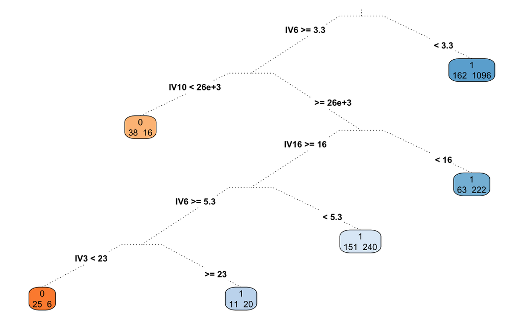

After also running the large tree and the logistic regression classifiers, we can then check how much “weight” these three methods put on the different default drivers:

|  | CART 1 | CART 2 | Logistic Regr. |
| --- | --- | --- | --- |
| loan_amnt | -0.043232831 | -0.221379297 | -0.50000000 |
| term | 0.160716414 | 0.183885281 | 0.52272727 |
| int_rate | 0.930434794 | 0.979159376 | 0.02272727 |
| installment | 0.171612337 | 0.426551480 | 0.52272727 |
| grade | 0.617225384 | 0.617538940 | 0.06818182 |
| sub_grade | -1.000000000 | -1.000000000 | -0.52272727 |
| emp_length_known | 0.000000000 | 0.004065755 | 0.68181818 |
| emp_length | 0.000000000 | 0.030942308 | 0.40909091 |
| home_renters | 0.000000000 | -0.008227725 | -0.15909091 |
| annual_inc | -0.290865336 | -0.520187397 | -0.29545455 |
| verification_status | 0.000000000 | -0.007154799 | -0.22727273 |
| issue_d | 0.029246393 | 0.060326838 | 0.31818182 |
| purpose_debt | 0.000000000 | -0.007668002 | -0.29545455 |
| addr_state_lat | 0.000000000 | -0.168540143 | -0.36363636 |
| addr_state_lon | -0.003595951 | -0.134731206 | -0.13636364 |
| dti | -0.204969216 | -0.391269578 | -1.00000000 |
| open_acc | 0.026968899 | 0.168016859 | 0.34090909 |
| pub_rec | 0.000000000 | 0.009977839 | 0.56818182 |

Finally, if we were to use the estimated classification models on the test data, we would get the following default curves (see the raw .Rmd file to select the business profit parameters).

The default curve using the small classification tree:

[interactive chart not shown]

The default curve using the large classification tree:

[interactive chart not shown]

The default curve using the logistic regression classifier:

[interactive chart not shown]

These are the maximum total profit achieved in the test data using the three classifiers (without any segment specific analysis so far).

|  | Percentile | Profit |
| --- | --- | --- |
| Small Tree | 100.00 | 17600 |
| Large Tree | 100.00 | 17600 |
| Logistic Regression | 98.44 | 17800 |